# SVM project- Tyson Foods Inc.

Jaime Duran

11/15/2019

# 1 Introduction

This is an implementation of a support vector machine designed to identify short-term stock price changes, based on previous stock parameters.This might be useful for day trades.

## 1.1 Stock selected for this exercise:

I selected Tyson Foods, Inc the world’s second largest producer and distributor of beef, chicken, and pork food products. Since population keeps rising, I think that big food companies like Tyson will have steady profits for long into the future. Tyson was founded in 1935, and has been a publicly traded company since 1963. It is a data rich company.

picture of the stock price

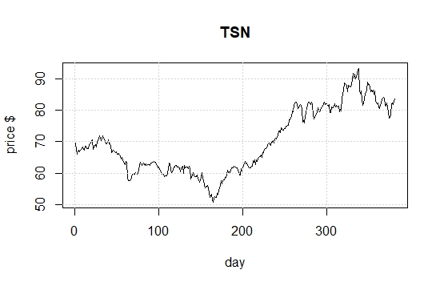

## 1.2 get data:

Name of the Columns price.open price.high price.low price.close volume price.adjusted ref.date ticker ret.adjusted.prices ret.closing.prices pctChange ChangeCategory

```r
tysondata = read.csv('tysonTrimmed.csv')
View(tysondata)
```

# 2 set up data frame

```r
# set up data frame
    tysondataFrame = data.frame(open=tysondata$price.open, high=tysondata$price.high,  low=tysondata$price.low, close=tysondata$price.close,volume= tysondata$volume/10000,
      change = tysondata$ChangeCategory )

# look at top and bottom..
head(tysondataFrame)
```

```
##    open  high   low close volume change
## 1 69.34 69.44 67.30 67.49 183.05      E
## 2 67.59 67.74 65.82 66.05 249.02      E
## 3 65.75 67.30 65.17 66.97 242.10      E
## 4 65.64 68.00 64.60 67.22 425.71      E
## 5 66.78 66.85 65.89 66.66 244.81      E
## 6 66.84 67.81 66.78 67.27 242.81      E
```

```r
tail(tysondataFrame)
```

```
##      open  high   low close volume change
## 351 87.11 87.57 85.68 85.79 166.68      E
## 352 86.40 86.90 85.57 86.28 126.91      D
## 353 86.48 87.48 85.82 85.97 189.70      D
## 354 86.44 86.86 85.90 86.46 117.67      D
## 355 86.60 86.61 84.96 85.20 163.79      D
## 356 85.37 86.26 84.79 86.14 211.63      D
```

```r
remove(tysondata)
```

```r
levels(tysondataFrame$change)
```

```
## [1] "D" "E" "U"
```

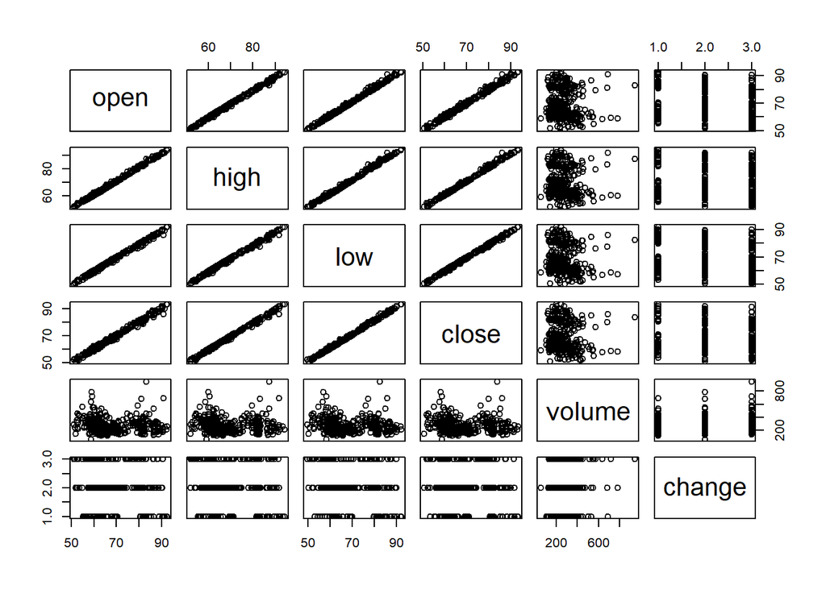

```r
plot(tysondataFrame)
```

## 2.1 classification model, categorical response

### 2.1.1 traditional interface:

```r
x <- subset(tysondataFrame[1:356,], select = -change)
y <- tysondataFrame[1:356,]$change
model1 <- svm(x, y)

#model1 is all the data
print(model1)
```

```
##
## Call:
## svm.default(x = x, y = y)
##
##
## Parameters:
##    SVM-Type:  C-classification
##  SVM-Kernel:  radial
##        cost:  1
##
## Number of Support Vectors:  285
```

```r
summary(model1)
```

```
##
## Call:
## svm.default(x = x, y = y)
##
##
## Parameters:
##    SVM-Type:  C-classification
##  SVM-Kernel:  radial
##        cost:  1
##
## Number of Support Vectors:  285
##
##  ( 133 86 66 )
##
##
## Number of Classes:  3
##
## Levels:
##  D E U
```

## 2.2 how well did the model fit?

```r
pred <- predict(model1, x)

# Check accuracy:
table(pred, y)
```

```
##     y
## pred   D   E   U
##    D   9   4   2
##    E  57 199  79
##    U   0   1   5
```

## 2.3 decision values

```r
# compute decision values and probabilities:
pred <- predict(model1, x, decision.values = TRUE)
attr(pred, "decision.values")[1:6,]
```

```
##         E/U       E/D       U/D
## 1 1.0006410 1.0042878 0.7800025
## 2 1.0034887 1.0006274 0.8654903
## 3 1.0026764 0.9985742 0.8348931
## 4 1.0291485 1.0019263 0.9782400
## 5 1.0013527 0.9997068 0.8463553
## 6 0.9999231 0.9985022 0.8901698
```

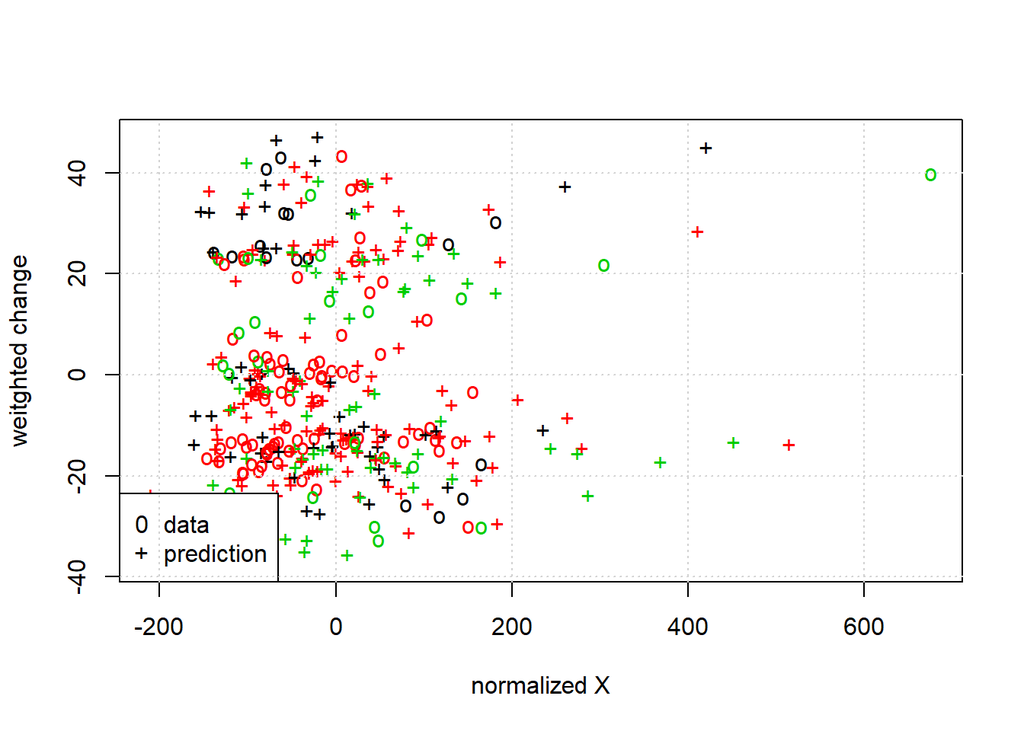

```r
# visualize (classes by color, SV by crosses):
plot(cmdscale(dist(tysondataFrame[,-6])),
     col = as.integer(tysondataFrame[,6]),xlab="normalized X", ylab = "weitghted change",
     pch = c("o","+")[1:150 %in% model1$index + 1])
legend('bottomleft',c('data','prediction'),pch=c('0','+'))
grid()
```

# 3 train and test set:

There are 356 rows in my data set. I’m selecting 70 % of data randomly, and they will be the training data. The remaining samples will be my test data set.

```r
pctTrain=0.70  # use about 70% of the data
nObs = length(x[,1])
nObs = 356
nTrain = round(pctTrain*nObs,0)

# next line take data in order
#TrainSetIndex = 1:nTrain

# These lines take a random sample
scramble = sample(1:nObs)
TrainSetIndex = scramble[1:nTrain]
TestSetIndex = scramble[(nTrain+1):nObs]
```

## 3.1 set up training set, test set

```r
# first the training set
tysondataFrame1 = tysondataFrame[1:356,]

XtrainSet = tysondataFrame1[TrainSetIndex,-6]
YtrainSet = tysondataFrame1$change[TrainSetIndex]
```

## 3.2 get the model from training set..

```r
model2 <- svm(XtrainSet, YtrainSet)

print(model2)
```

```
##
## Call:
## svm.default(x = XtrainSet, y = YtrainSet)
##
##
## Parameters:
##    SVM-Type:  C-classification
##  SVM-Kernel:  radial
##        cost:  1
##
## Number of Support Vectors:  200
```

```r
summary(model2)
```

```
##
## Call:
## svm.default(x = XtrainSet, y = YtrainSet)
##
##
## Parameters:
##    SVM-Type:  C-classification
##  SVM-Kernel:  radial
##        cost:  1
##
## Number of Support Vectors:  200
##
##  ( 95 53 52 )
##
##
## Number of Classes:  3
##
## Levels:
##  D E U
```

## 3.3 now the test set..

```r
XtestSet = tysondataFrame1[(TestSetIndex),-6]
YtestSet = tysondataFrame1$change[TestSetIndex]
```

## 3.4 and evaluate with the test data

```r
pred2 <- predict(model2, XtestSet)
# And the accuracy..

table(pred2, YtestSet)
```

```
##      YtestSet
## pred2  D  E  U
##     D  2  2  1
##     E 12 58 32
##     U  0  0  0
```

## 3.5 tune

```r
stockTuned <- tune.svm(XtrainSet, YtrainSet, gamma = 2^(-2:1), cost = 2^(1:4))

summary(stockTuned)
```

```
##
## Parameter tuning of 'svm':
##
## - sampling method: 10-fold cross validation
##
## - best parameters:
##  gamma cost
##    0.5    2
##
## - best performance: 0.4055
##
## - Detailed performance results:
##    gamma cost     error dispersion
## 1   0.25    2 0.4295000 0.12143700
## 2   0.50    2 0.4055000 0.12522092
## 3   1.00    2 0.4455000 0.11884747
## 4   2.00    2 0.4496667 0.09684466
## 5   0.25    4 0.4175000 0.11272508
## 6   0.50    4 0.4295000 0.11388225
## 7   1.00    4 0.4416667 0.10940072
## 8   2.00    4 0.4418333 0.11484410
## 9   0.25    8 0.4175000 0.11429129
## 10  0.50    8 0.4455000 0.11581715
## 11  1.00    8 0.4498333 0.13439956
## 12  2.00    8 0.4418333 0.12378409
## 13  0.25   16 0.4215000 0.12037095
## 14  0.50   16 0.4335000 0.11498913
## 15  1.00   16 0.4535000 0.12823698
## 16  2.00   16 0.4378333 0.12870689
```

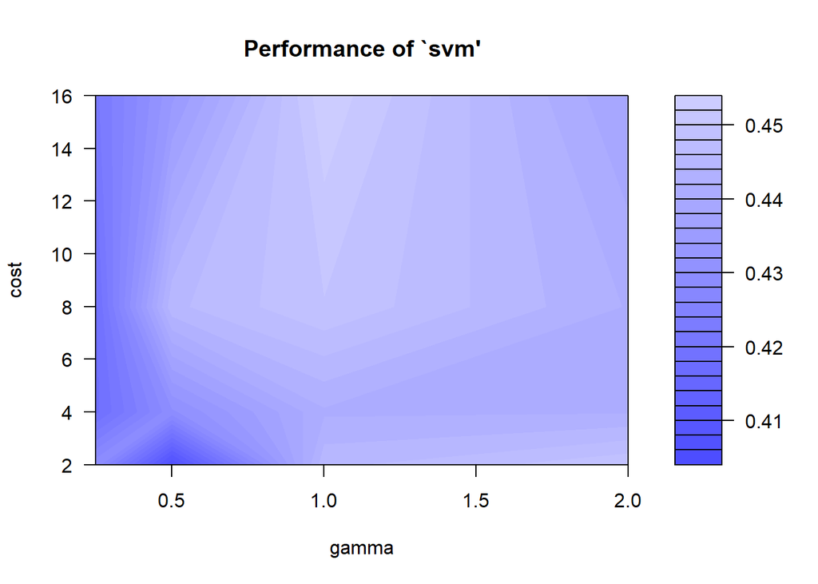

```r
plot(stockTuned)
```

```r
print(paste('best parameters: gamma=',stockTuned$best.parameters[1], ', cost=', stockTuned$best.parameters[2]))
```

```
## [1] "best parameters: gamma= 0.5 , cost= 2"
```

```r
#use optimized parameters...
model3 <- svm(XtrainSet, YtrainSet, gamma=as.numeric(stockTuned$best.parameters[1]), cost=as.numeric(stockTuned$best.parameters[2] ))

print(model3)
```

```
##
## Call:
## svm.default(x = XtrainSet, y = YtrainSet, gamma = as.numeric(stockTuned$best.parameters[1]),
##     cost = as.numeric(stockTuned$best.parameters[2]))
##
##
## Parameters:
##    SVM-Type:  C-classification
##  SVM-Kernel:  radial
##        cost:  2
##
## Number of Support Vectors:  199
```

```r
summary(model3)
```

```
##
## Call:
## svm.default(x = XtrainSet, y = YtrainSet, gamma = as.numeric(stockTuned$best.parameters[1]),
##     cost = as.numeric(stockTuned$best.parameters[2]))
##
##
## Parameters:
##    SVM-Type:  C-classification
##  SVM-Kernel:  radial
##        cost:  2
##
## Number of Support Vectors:  199
##
##  ( 96 53 50 )
##
##
## Number of Classes:  3
##
## Levels:
##  D E U
```

```r
pred3 <- predict(model3, XtestSet)
# And the accuracy..

table(pred3, YtestSet)
```

```
##      YtestSet
## pred3  D  E  U
##     D  2  3  1
##     E 12 55 25
##     U  0  2  7
```

Now use the last 11 values to see how we do

```r
XtestSetFortheMoney = tysondataFrame[346:356,-6]
YtestSetFortheMoney  = tysondataFrame[346:356,6]

pred4 <- predict(model3, XtestSetFortheMoney)
# And the accuracy..
print(pred4)
```

```
## 346 347 348 349 350 351 352 353 354 355 356
##   D   E   D   D   E   D   D   D   D   D   D
## Levels: D E U
```

```r
#table(pred4, YtestSetFortheMoney)
```

The actual results for Sept 16 - Sept 30 were

346 347 348 349 350 351 352 353 354 355 356

D E D E E E D D D D D

```r
# compute decision values and probabilities:
pred <- predict(model3, XtestSet, decision.values = TRUE)
attr(pred, "decision.values")[1:5,]
```

```
##            E/U        E/D        U/D
## 49   1.0059882  0.9673250 -0.7586424
## 203  0.9909159  0.9987556 -0.1474042
## 329  0.8195492 -0.4697601 -0.6786959
## 164 -0.5832892  0.7506584  1.1575298
## 269  0.9283173  1.1125912  0.1395647
```

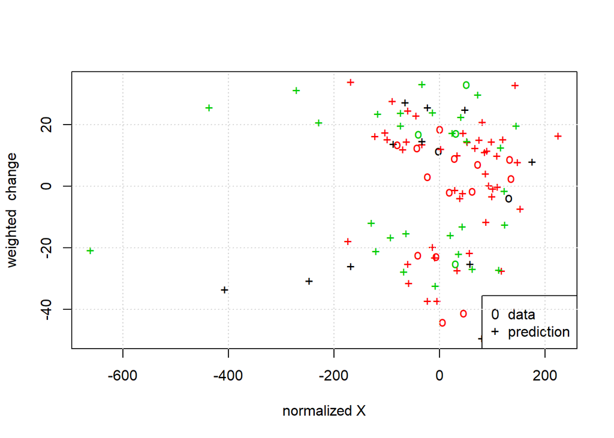

```r
# visualize (classes by color, SV by crosses):
plot(cmdscale(dist(XtestSet)),
     col = as.integer(YtestSet),xlab="normalized X", ylab = "weighted  change",
     pch = c("o","+")[1:150 %in% model3$index + 1])
legend('bottomright',c('data','prediction'),pch=c('0','+'))
grid()
```

# 4 SVM assignment

## 4.1 complete an rmarkdown file on the stock you selected.

url address https://github.com/jdwarp/SVMtemplate.git

### 4.1.1 Identify the stock you use for this assignment.

The stock seemed to have a lot of variation, so I figured it would be worthwhile to test the predictive power of the support vector machine.

### 4.1.2 Use this template to get the SVM:

1. Training and Test sets:  
   I used 70 percent of the data as the training set. I randomized the selection of test data. I used randomization data because there was a lot of variance in the stock price of Tyson Foods Inc. Random data sets make more sense than randomly choosing one time to study based on chronological order. The one observable difference is that Tyson stock has risen steadily since its lowpoint at 12/24/2018 with a closing price $50.75.

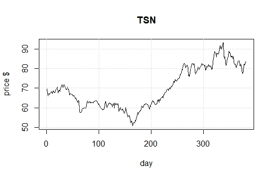

2. How well did the SVM do?  
   The SVM did well when predicting the date range from Sept 16th to Sept 30th. The SVM won 9 bets and lost 2, so it would have a positive ROI.

Predicted Data Set

```r
print(pred4)
```

```
## 346 347 348 349 350 351 352 353 354 355 356
##   D   E   D   D   E   D   D   D   D   D   D
## Levels: D E U
```

Actual Data Set The actual results for Sept 16 - Sept 30 were 346 347 348 349 350 351 352 353 354 355 356 D E D E E E D D D D D

3. Tuning to SVM. The following are the best performing parameters for tuning the svm.

```r
print(paste('best parameters: gamma=',stockTuned$best.parameters[1], ', cost=', stockTuned$best.parameters[2]))
```

```
## [1] "best parameters: gamma= 0.5 , cost= 2"
```

### 4.1.3 Evaluate SVM performance

ROI = 9 wins - 2 errors. In this example I would gain 7000 dollars if you get 1000 dollars for each correct prediction and lose 1000 if otherwise.

3. Would you put your own $$ in this SVM?
   No, this SVM was training on its own self contained and incomplete data set so its good performance isn’t consistent when you rerun the test. The SVM tool is effective as a learning tool but its predictive values aren’t related to the all of the changes in the real world that impacts actual stock price. Too much confidence in the SVM would make me poor, and my computer isn’t fast enough to run the necessary data.